# Search: Solving a Maze Using a Goal-based Agent

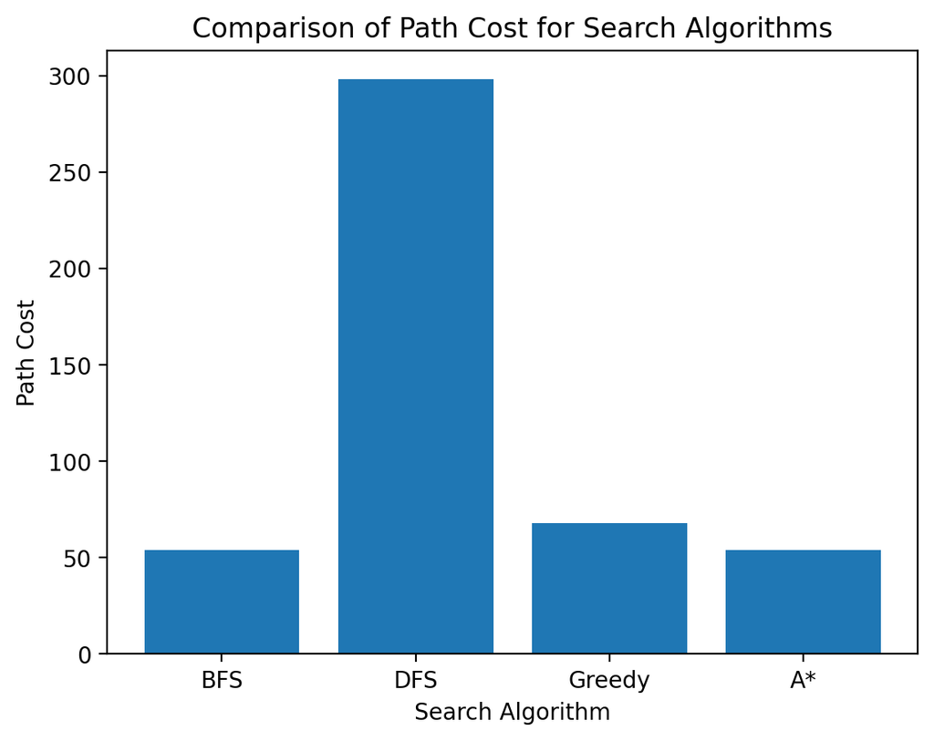

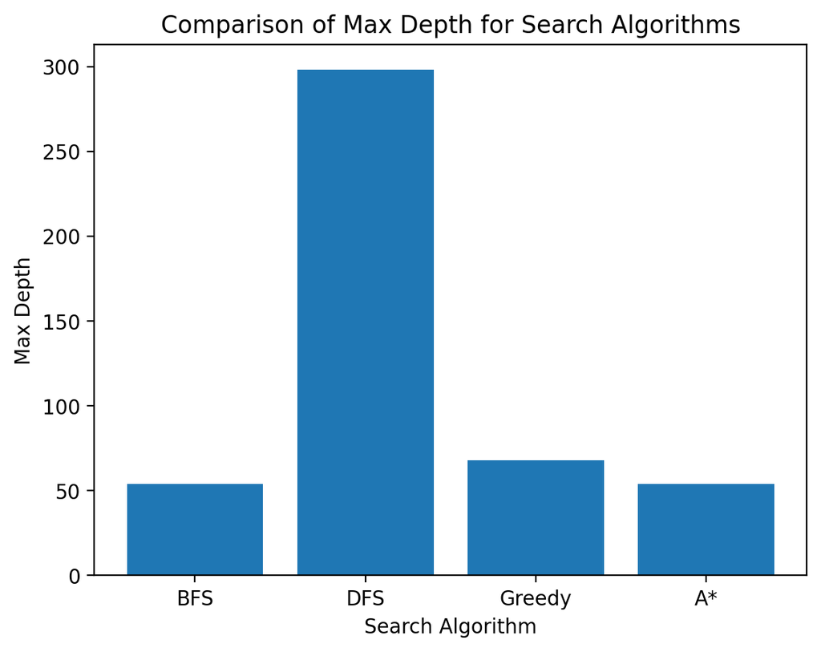

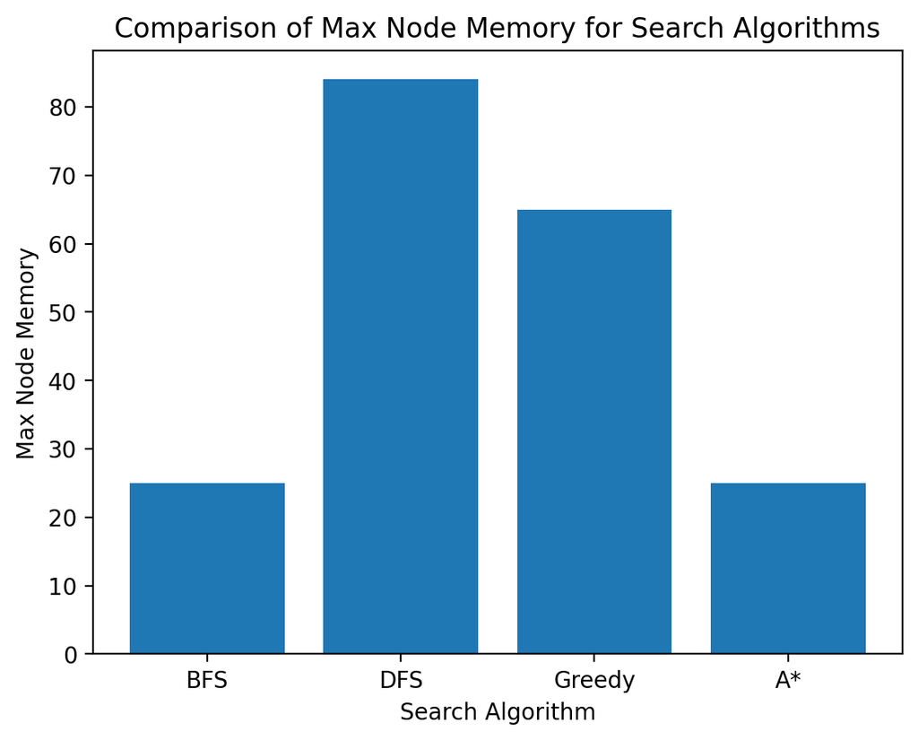

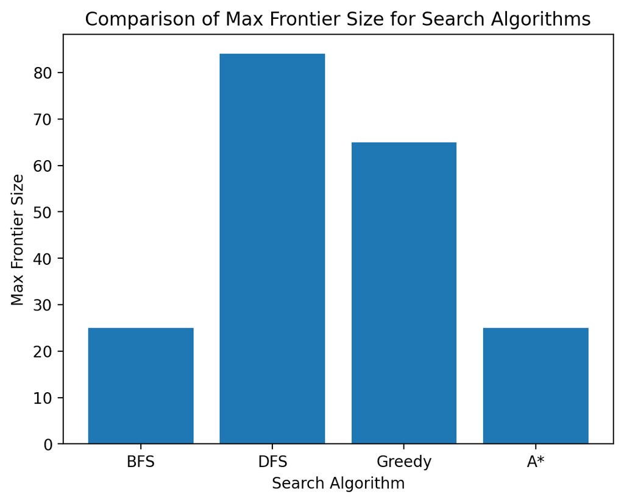

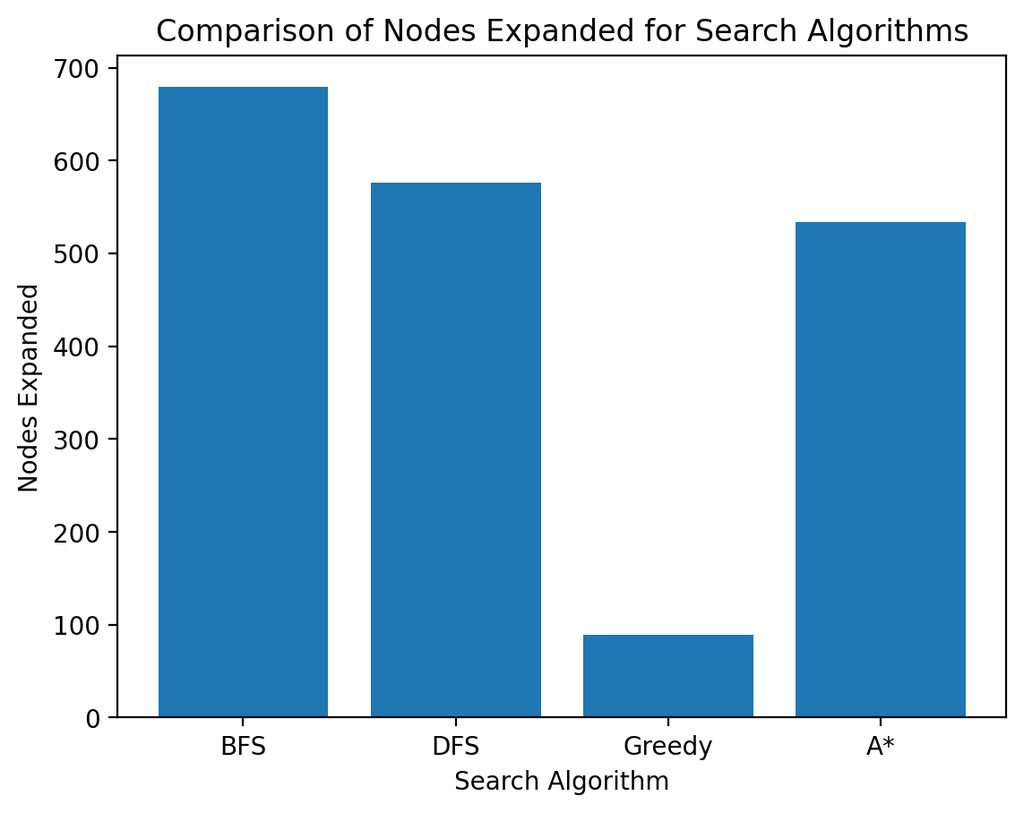

```python
# Generate the charts
path_costs = [result[1], resultdepth[1], resultgreedy[1], resulta[1]]
max_depths = [result[2], resultdepth[2], resultgreedy[2], resulta[2]]
max_node_memories = [result[3], resultdepth[3], resultgreedy[3], resulta[3]]
max_frontiers = [result[4], resultdepth[4], resultgreedy[4], resulta[4]]
nodes_expanded = [result[5], resultdepth[5], resultgreedy[5], resulta[5]]
metrics = {
    'Path Cost': path_costs,
    'Max Depth': max_depths,
    'Max Node Memory': max_node_memories,
    'Max Frontier Size': max_frontiers,
    'Nodes Expanded': nodes_expanded
}
for metric_name, values in metrics.items():
    plt.figure()
    plt.bar(algorithms, values)
    plt.title(f'Comparison of {metric_name} for Search Algorithms')
    plt.xlabel('Search Algorithm')
    plt.ylabel(metric_name)
    plt.show()
```

```
XXXXXXXXXXXX
X          X
X        G X
X          X
X   XXXX   X
X      X   X
X      X   X
X      X   X
X          X
X S        X
X          X
XXXXXXXXXXXX
```

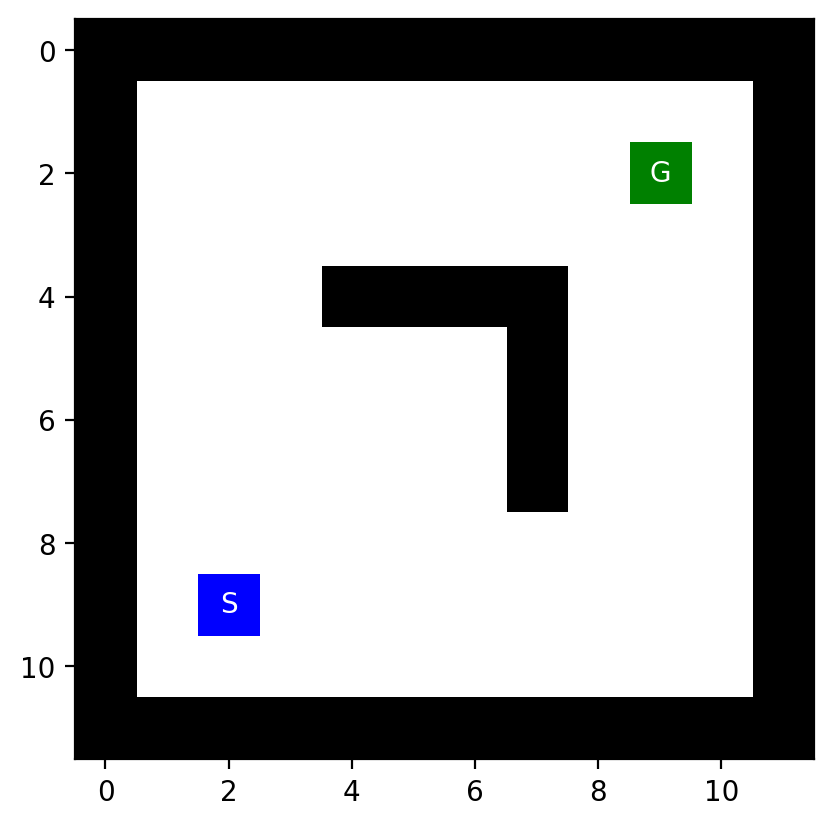

```
Path Cost: 14 ; Max Depth: 14 ; Max # of Nodes in Memory: 11 ; Max Frontier Size: 11 ; # of Nodes Expanded: 85
```

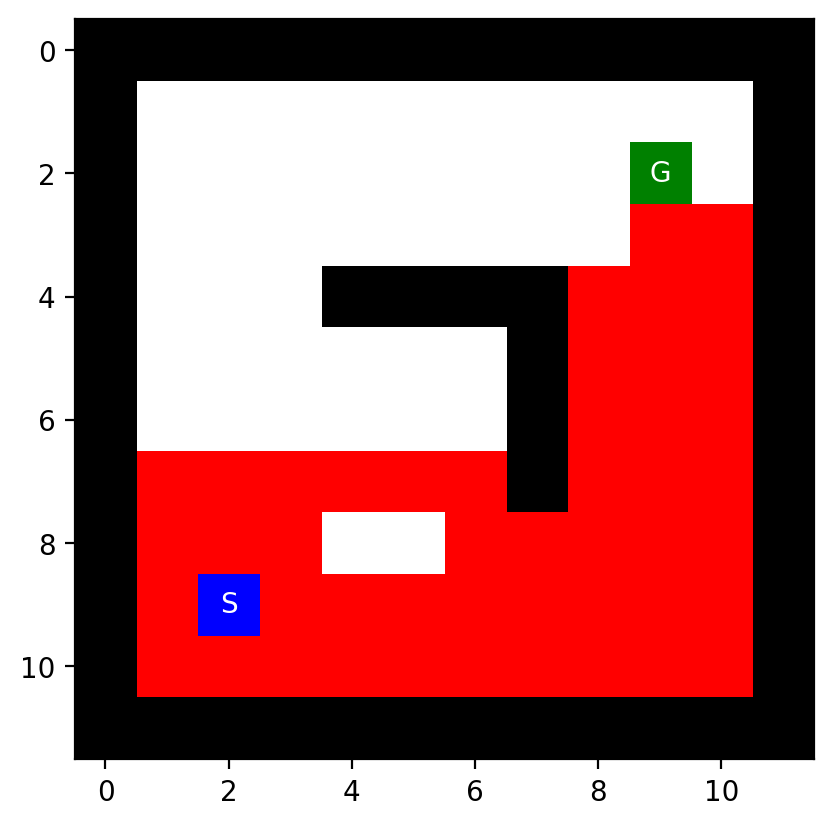

```
Path Cost: 48 ; Max Depth: 48 ; Max Node Memory: 13 ; Max Frontier: 13 ; Nodes Expanded: 50
```

```
Path Cost: 14 ; Max Depth: 14 ; Max Node Memory: 27 ; Max Frontier: 27 ; Nodes Expanded: 14
```

```
Path Cost: 14 ; Max Depth: 14 ; Max Node Memory: 30 ; Max Frontier: 30 ; Nodes Expanded: 55
```

```python
# Add code
with open("wall_maze.txt", "r") as f:
    maze_str = f.read()
maze = mh.parse_maze(maze_str)
print(maze_str)
mh.show_maze(maze)

# BFS
result = breadth_first_search(maze, mh.find_pos(maze, "S"), mh.find_pos(maze, "G"))
for node in result[0]:
    if maze[node.pos] not in ["S", "G"]:
        maze[node.pos] = "P"
mh.show_maze(maze)
print('Path Cost:', result[1], '; Max Depth:', result[2], '; Max # of Nodes in Memory:', result[3], '; Max Frontier Size:', result[4], '; # of Nodes Expanded:', result[5])

# DFS
resultdepth = depth_first_search(maze, mh.find_pos(maze, "S"), mh.find_pos(maze, "G"))
maze = mh.parse_maze(maze_str)
for node in resultdepth[0]:
    if maze[node.pos] not in ["S", "G"]:
        maze[node.pos] = "P"
mh.show_maze(maze)
print('Path Cost:', resultdepth[1], '; Max Depth:', resultdepth[2], '; Max Node Memory:', resultdepth[3], '; Max Frontier:', resultdepth[4], '; Nodes Expanded:', resultdepth[5])

# Greedy search
resultgreedy = greedy_best_first_search(maze, mh.find_pos(maze, "S"), mh.find_pos(maze, "G"))
maze = mh.parse_maze(maze_str)
for node in resultgreedy[0]:
    if maze[node.pos] not in ["S", "G"]:
        maze[node.pos] = "P"
mh.show_maze(maze)
print('Path Cost:', resultgreedy[1], '; Max Depth:', resultgreedy[2], '; Max Node Memory:', resultgreedy[3], '; Max Frontier:', resultgreedy[4], '; Nodes Expanded:', resultgreedy[5])

# a* search
resulta = a_breadth_first_search(maze, mh.find_pos(maze, "S"), mh.find_pos(maze, "G"))
maze = mh.parse_maze(maze_str)
for node in resulta[0]:
    if maze[node.pos] not in ["S", "G"]:
        maze[node.pos] = "P"
mh.show_maze(maze)
print('Path Cost:', resulta[1], '; Max Depth:', resulta[2], '; Max Node Memory:', resulta[3], '; Max Frontier:', resulta[4], '; Nodes Expanded:', resulta[5])
```

[output not shown]

```python
# Table
results = [
    ['BFS', result[1], result[2], result[3], result[4], result[5]],
    ['DFS', resultdepth[1], resultdepth[2], resultdepth[3], resultdepth[4], resultdepth[5]],
    ['Greedy Best-First', resultgreedy[1], resultgreedy[2], resultgreedy[3], resultgreedy[4], resultgreedy[5]],
    ['A* Search', resulta[1], resulta[2], resulta[3], resulta[4], resulta[5]]
]

columns = ['Algorithm', 'Path Cost', 'Max Depth', 'Max Nodes in Memory', 'Max Frontier Size', 'Nodes Expanded']

table = tabulate(results, headers=columns, tablefmt='grid')
print("Wall Maze")
print(table)
```

```
Wall Maze
+-------------------+-------------+-------------+-----------------------+---------------------+------------------+
| Algorithm         |   Path Cost |   Max Depth |   Max Nodes in Memory |   Max Frontier Size |   Nodes Expanded |
+===================+=============+=============+=======================+=====================+==================+
| BFS               |          14 |          14 |                    11 |                  11 |               85 |
+-------------------+-------------+-------------+-----------------------+---------------------+------------------+
| DFS               |          48 |          48 |                    13 |                  13 |               50 |
+-------------------+-------------+-------------+-----------------------+---------------------+------------------+
| Greedy Best-First |          14 |          14 |                    27 |                  27 |               14 |
+-------------------+-------------+-------------+-----------------------+---------------------+------------------+
| A* Search         |          14 |          14 |                    30 |                  30 |               55 |
+-------------------+-------------+-------------+-----------------------+---------------------+------------------+
```

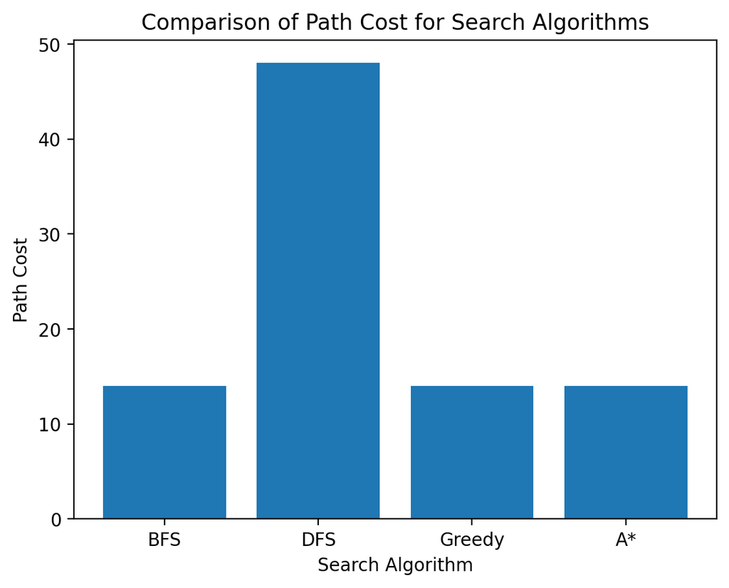

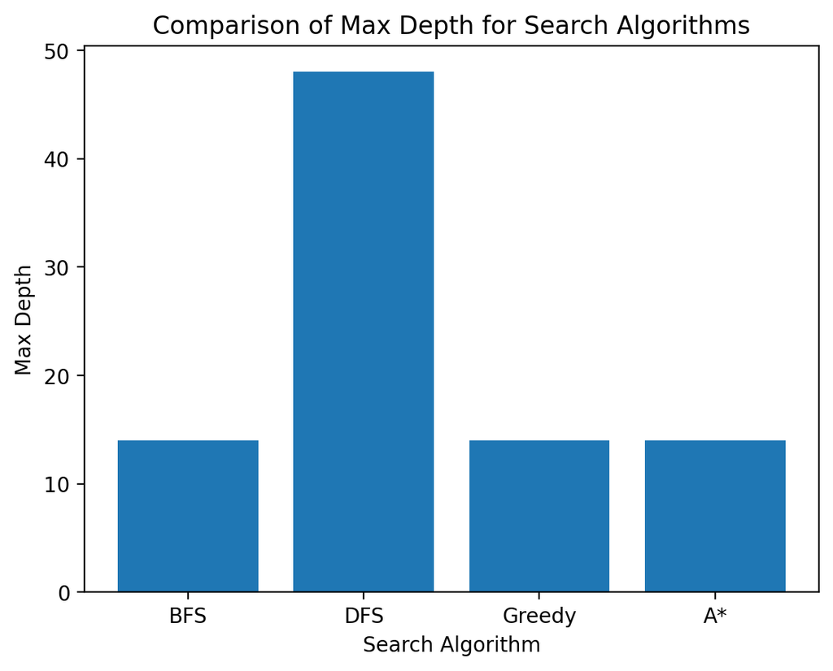

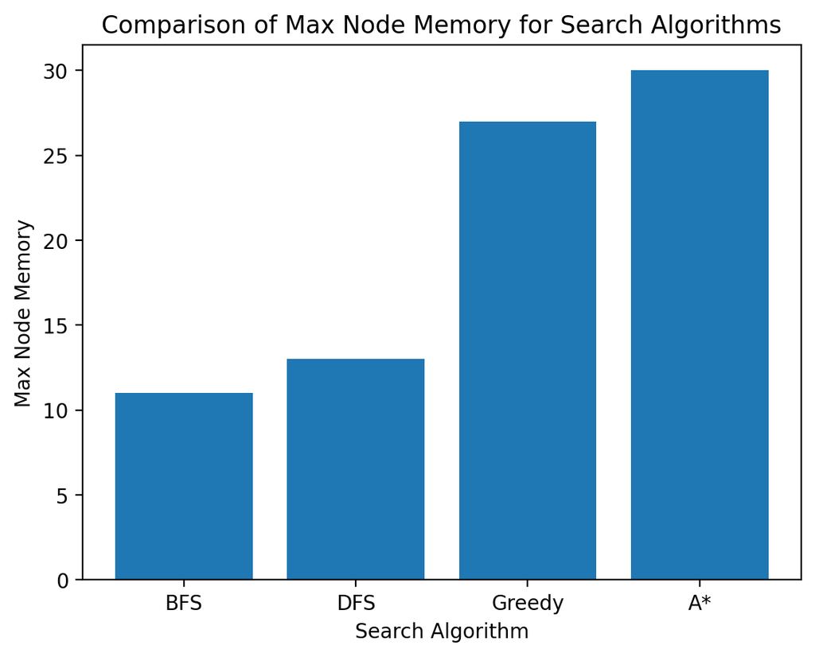

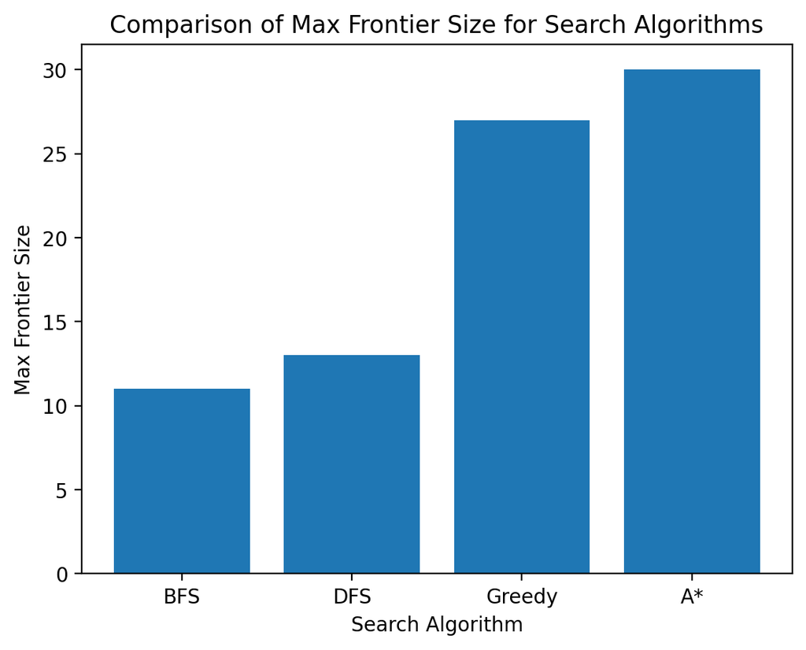

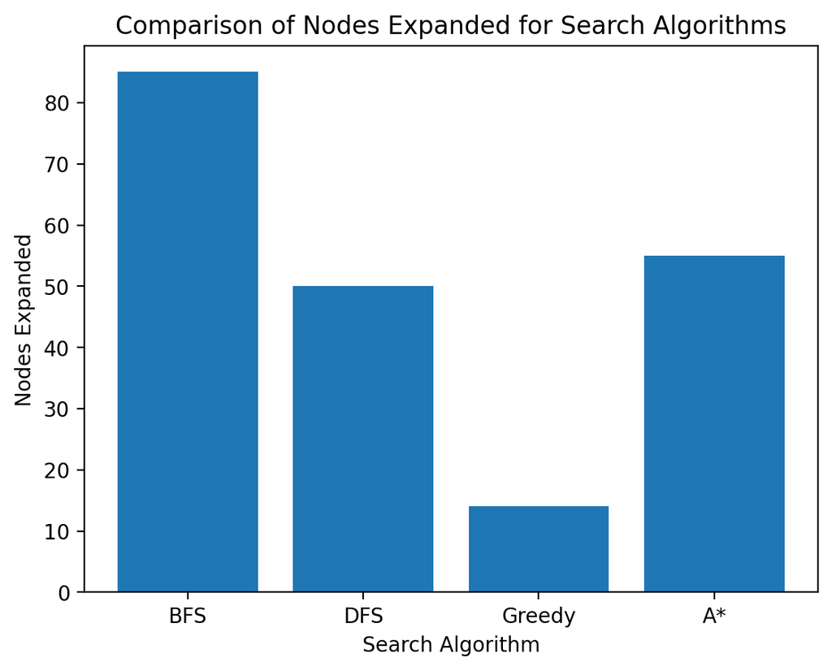

```python
# Generate the charts
path_costs = [result[1], resultdepth[1], resultgreedy[1], resulta[1]]
max_depths = [result[2], resultdepth[2], resultgreedy[2], resulta[2]]
max_node_memories = [result[3], resultdepth[3], resultgreedy[3], resulta[3]]
max_frontiers = [result[4], resultdepth[4], resultgreedy[4], resulta[4]]
nodes_expanded = [result[5], resultdepth[5], resultgreedy[5], resulta[5]]
metrics = {
    'Path Cost': path_costs,
    'Max Depth': max_depths,
    'Max Node Memory': max_node_memories,
    'Max Frontier Size': max_frontiers,
    'Nodes Expanded': nodes_expanded
}
for metric_name, values in metrics.items():
    plt.figure()
    plt.bar(algorithms, values)
    plt.title(f'Comparison of {metric_name} for Search Algorithms')
    plt.xlabel('Search Algorithm')
    plt.ylabel(metric_name)
    plt.show()
```

```
XXXXXXXXXXXX
XG         X
X        X X
XXXXXXXX X X
X      X X X
X    X X X X
X    X X   X
X    X X X X
X    X X X X
XXXX X X X X
XS         X
XXXXXXXXXXXX
```

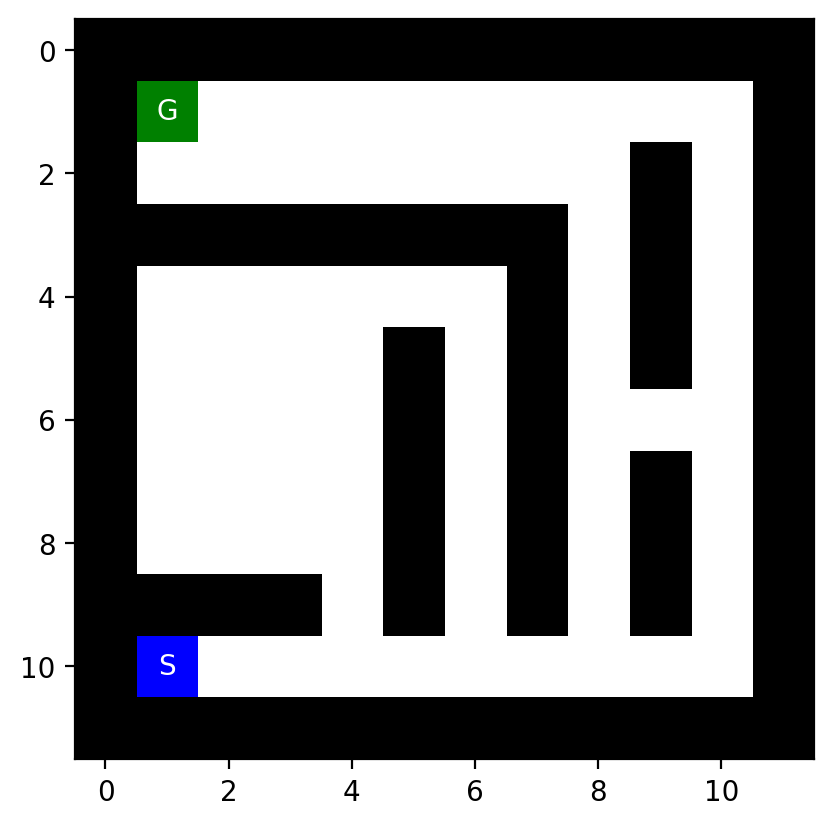

```
Path Cost: 23 ; Max Depth: 23 ; Max # of Nodes in Memory: 8 ; Max Frontier Size: 8 ; # of Nodes Expanded: 70
```

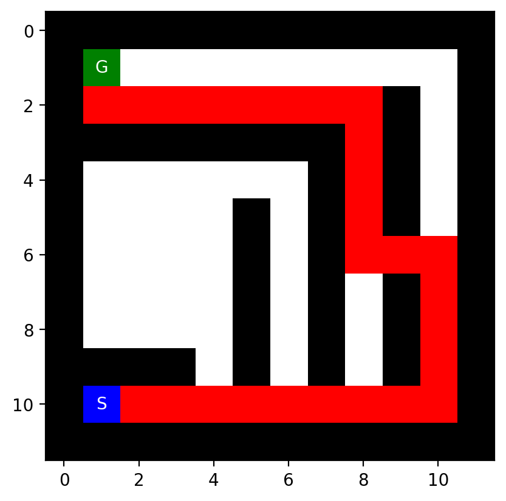

```
Path Cost: 27 ; Max Depth: 27 ; Max Node Memory: 11 ; Max Frontier: 11 ; Nodes Expanded: 30
```

```
Path Cost: 23 ; Max Depth: 23 ; Max Node Memory: 9 ; Max Frontier: 9 ; Nodes Expanded: 51
```

```
Path Cost: 23 ; Max Depth: 23 ; Max Node Memory: 6 ; Max Frontier: 6 ; Nodes Expanded: 58
```

```python
# Add code
with open("loops_maze.txt", "r") as f:
    maze_str = f.read()
maze = mh.parse_maze(maze_str)
print(maze_str)
mh.show_maze(maze)

# BFS
result = breadth_first_search(maze, mh.find_pos(maze, "S"), mh.find_pos(maze, "G"))
for node in result[0]:
    if maze[node.pos] not in ["S", "G"]:
        maze[node.pos] = "P"
mh.show_maze(maze)
print('Path Cost:', result[1], '; Max Depth:', result[2], '; Max # of Nodes in Memory:', result[3], '; Max Frontier Size:', result[4], '; # of Nodes Expanded:', result[5])

# DFS
resultdepth = depth_first_search(maze, mh.find_pos(maze, "S"), mh.find_pos(maze, "G"))
maze = mh.parse_maze(maze_str)
for node in resultdepth[0]:
    if maze[node.pos] not in ["S", "G"]:
        maze[node.pos] = "P"
mh.show_maze(maze)
print('Path Cost:', resultdepth[1], '; Max Depth:', resultdepth[2], '; Max Node Memory:', resultdepth[3], '; Max Frontier:', resultdepth[4], '; Nodes Expanded:', resultdepth[5])

# Greedy search
resultgreedy = greedy_best_first_search(maze, mh.find_pos(maze, "S"), mh.find_pos(maze, "G"))
maze = mh.parse_maze(maze_str)
for node in resultgreedy[0]:
    if maze[node.pos] not in ["S", "G"]:
        maze[node.pos] = "P"
mh.show_maze(maze)
print('Path Cost:', resultgreedy[1], '; Max Depth:', resultgreedy[2], '; Max Node Memory:', resultgreedy[3], '; Max Frontier:', resultgreedy[4], '; Nodes Expanded:', resultgreedy[5])

# a* search
resulta = a_breadth_first_search(maze, mh.find_pos(maze, "S"), mh.find_pos(maze, "G"))
maze = mh.parse_maze(maze_str)
for node in resulta[0]:
    if maze[node.pos] not in ["S", "G"]:
        maze[node.pos] = "P"
mh.show_maze(maze)
print('Path Cost:', resulta[1], '; Max Depth:', resulta[2], '; Max Node Memory:', resulta[3], '; Max Frontier:', resulta[4], '; Nodes Expanded:', resulta[5])
```

[output not shown]

```python
# Table
results = [
    ['BFS', result[1], result[2], result[3], result[4], result[5]],
    ['DFS', resultdepth[1], resultdepth[2], resultdepth[3], resultdepth[4], resultdepth[5]],
    ['Greedy Best-First', resultgreedy[1], resultgreedy[2], resultgreedy[3], resultgreedy[4], resultgreedy[5]],
    ['A* Search', resulta[1], resulta[2], resulta[3], resulta[4], resulta[5]]
]

columns = ['Algorithm', 'Path Cost', 'Max Depth', 'Max Nodes in Memory', 'Max Frontier Size', 'Nodes Expanded']

table = tabulate(results, headers=columns, tablefmt='grid')
print("Loops Maze")
print(table)
```

```
Loops Maze
+-------------------+-------------+-------------+-----------------------+---------------------+------------------+
| Algorithm         |   Path Cost |   Max Depth |   Max Nodes in Memory |   Max Frontier Size |   Nodes Expanded |
+===================+=============+=============+=======================+=====================+==================+
| BFS               |          23 |          23 |                     8 |                   8 |               70 |
+-------------------+-------------+-------------+-----------------------+---------------------+------------------+
| DFS               |          27 |          27 |                    11 |                  11 |               30 |
+-------------------+-------------+-------------+-----------------------+---------------------+------------------+
| Greedy Best-First |          23 |          23 |                     9 |                   9 |               51 |
+-------------------+-------------+-------------+-----------------------+---------------------+------------------+
| A* Search         |          23 |          23 |                     6 |                   6 |               58 |
+-------------------+-------------+-------------+-----------------------+---------------------+------------------+
```

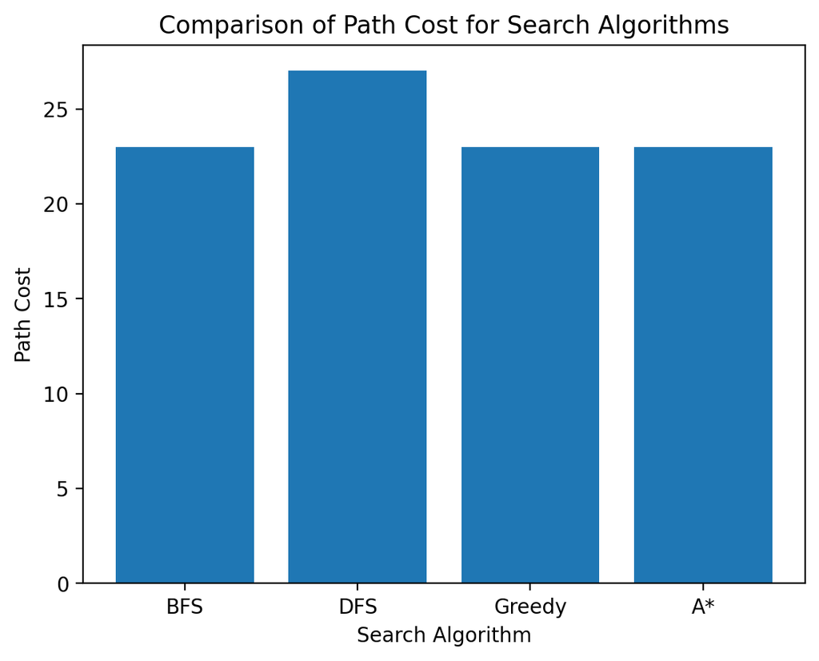

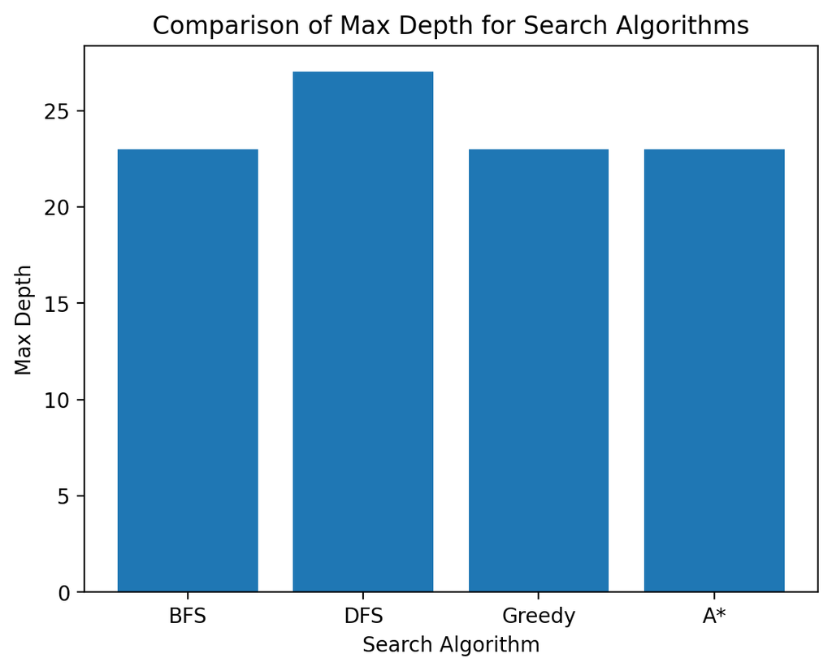

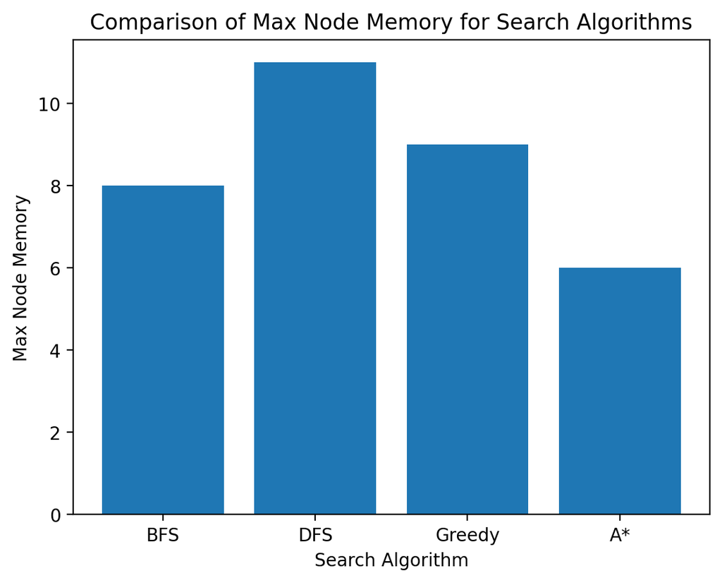

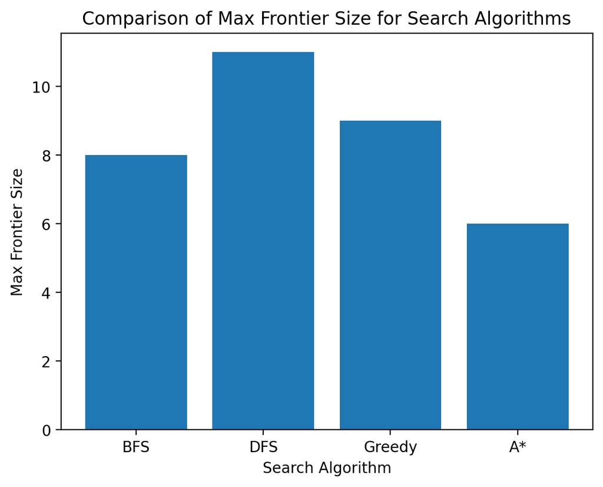

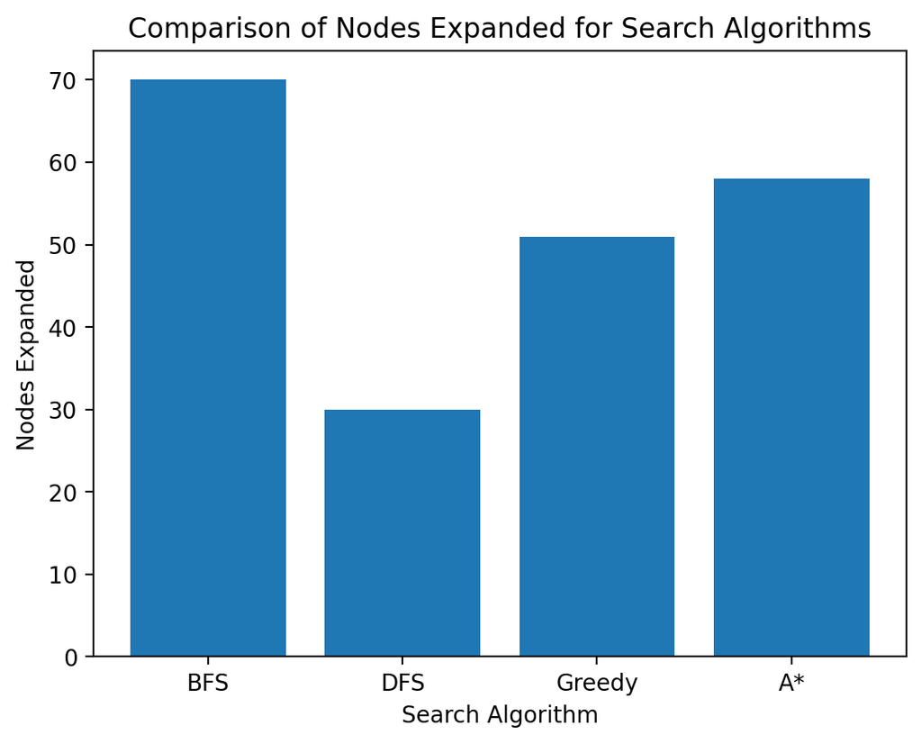

```python
# Generate the charts
path_costs = [result[1], resultdepth[1], resultgreedy[1], resulta[1]]
max_depths = [result[2], resultdepth[2], resultgreedy[2], resulta[2]]
max_node_memories = [result[3], resultdepth[3], resultgreedy[3], resulta[3]]
max_frontiers = [result[4], resultdepth[4], resultgreedy[4], resulta[4]]
nodes_expanded = [result[5], resultdepth[5], resultgreedy[5], resulta[5]]
metrics = {
    'Path Cost': path_costs,
    'Max Depth': max_depths,
    'Max Node Memory': max_node_memories,
    'Max Frontier Size': max_frontiers,
    'Nodes Expanded': nodes_expanded
}
for metric_name, values in metrics.items():
    plt.figure()
    plt.bar(algorithms, values)
    plt.title(f'Comparison of {metric_name} for Search Algorithms')
    plt.xlabel('Search Algorithm')
    plt.ylabel(metric_name)
    plt.show()
```

```
XXXXXXXXXXXX
X          X
X        G X
X          X
X          X
X          X
X          X
X          X
X          X
X S        X
X          X
XXXXXXXXXXXX
```

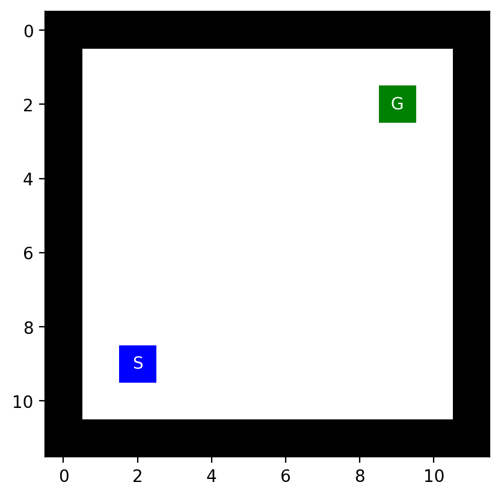

```
Path Cost: 14 ; Max Depth: 14 ; Max # of Nodes in Memory: 12 ; Max Frontier Size: 12 ; # of Nodes Expanded: 92
```

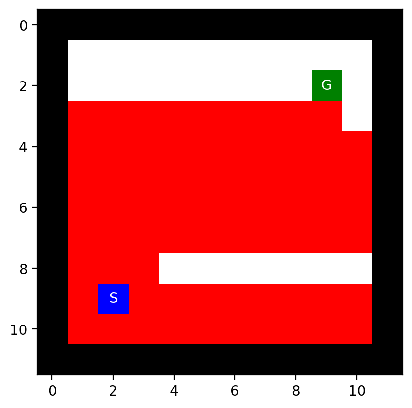

```
Path Cost: 72 ; Max Depth: 72 ; Max Node Memory: 17 ; Max Frontier: 17 ; Nodes Expanded: 79
```

```
Path Cost: 14 ; Max Depth: 14 ; Max Node Memory: 27 ; Max Frontier: 27 ; Nodes Expanded: 14
```

```
Path Cost: 14 ; Max Depth: 14 ; Max Node Memory: 30 ; Max Frontier: 30 ; Nodes Expanded: 62
```

```python
# Add code
with open("empty_maze.txt", "r") as f:
    maze_str = f.read()
maze = mh.parse_maze(maze_str)
print(maze_str)
mh.show_maze(maze)

# BFS
result = breadth_first_search(maze, mh.find_pos(maze, "S"), mh.find_pos(maze, "G"))
for node in result[0]:
    if maze[node.pos] not in ["S", "G"]:
        maze[node.pos] = "P"
mh.show_maze(maze)
print('Path Cost:', result[1], '; Max Depth:', result[2], '; Max # of Nodes in Memory:', result[3], '; Max Frontier Size:', result[4], '; # of Nodes Expanded:', result[5])

# DFS
resultdepth = depth_first_search(maze, mh.find_pos(maze, "S"), mh.find_pos(maze, "G"))
maze = mh.parse_maze(maze_str)
for node in resultdepth[0]:
    if maze[node.pos] not in ["S", "G"]:
        maze[node.pos] = "P"
mh.show_maze(maze)
print('Path Cost:', resultdepth[1], '; Max Depth:', resultdepth[2], '; Max Node Memory:', resultdepth[3], '; Max Frontier:', resultdepth[4], '; Nodes Expanded:', resultdepth[5])

# Greedy search
resultgreedy = greedy_best_first_search(maze, mh.find_pos(maze, "S"), mh.find_pos(maze, "G"))
maze = mh.parse_maze(maze_str)
for node in resultgreedy[0]:
    if maze[node.pos] not in ["S", "G"]:
        maze[node.pos] = "P"
mh.show_maze(maze)
print('Path Cost:', resultgreedy[1], '; Max Depth:', resultgreedy[2], '; Max Node Memory:', resultgreedy[3], '; Max Frontier:', resultgreedy[4], '; Nodes Expanded:', resultgreedy[5])

# a* search
resulta = a_breadth_first_search(maze, mh.find_pos(maze, "S"), mh.find_pos(maze, "G"))
maze = mh.parse_maze(maze_str)
for node in resulta[0]:
    if maze[node.pos] not in ["S", "G"]:
        maze[node.pos] = "P"
mh.show_maze(maze)
print('Path Cost:', resulta[1], '; Max Depth:', resulta[2], '; Max Node Memory:', resulta[3], '; Max Frontier:', resulta[4], '; Nodes Expanded:', resulta[5])
```

[output not shown]

```python
# Table
results = [
    ['BFS', result[1], result[2], result[3], result[4], result[5]],
    ['DFS', resultdepth[1], resultdepth[2], resultdepth[3], resultdepth[4], resultdepth[5]],
    ['Greedy Best-First', resultgreedy[1], resultgreedy[2], resultgreedy[3], resultgreedy[4], resultgreedy[5]],
    ['A* Search', resulta[1], resulta[2], resulta[3], resulta[4], resulta[5]]
]

columns = ['Algorithm', 'Path Cost', 'Max Depth', 'Max Nodes in Memory', 'Max Frontier Size', 'Nodes Expanded']

table = tabulate(results, headers=columns, tablefmt='grid')
print("Empty Maze")
print(table)
```

```
Empty Maze
+-------------------+-------------+-------------+-----------------------+---------------------+------------------+
| Algorithm         |   Path Cost |   Max Depth |   Max Nodes in Memory |   Max Frontier Size |   Nodes Expanded |
+===================+=============+=============+=======================+=====================+==================+
| BFS               |          14 |          14 |                    12 |                  12 |               92 |
+-------------------+-------------+-------------+-----------------------+---------------------+------------------+
| DFS               |          72 |          72 |                    17 |                  17 |               79 |
+-------------------+-------------+-------------+-----------------------+---------------------+------------------+
| Greedy Best-First |          14 |          14 |                    27 |                  27 |               14 |
+-------------------+-------------+-------------+-----------------------+---------------------+------------------+
| A* Search         |          14 |          14 |                    30 |                  30 |               62 |
+-------------------+-------------+-------------+-----------------------+---------------------+------------------+
```

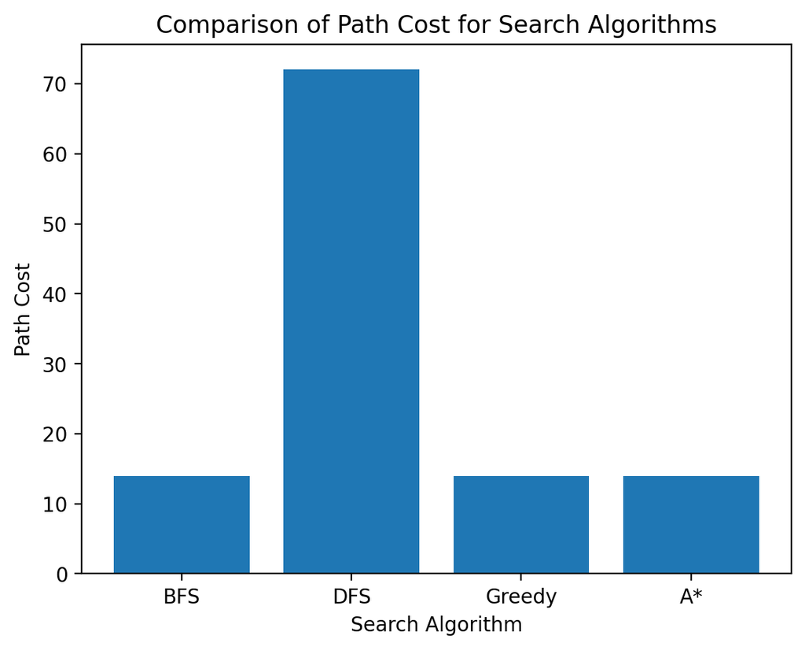

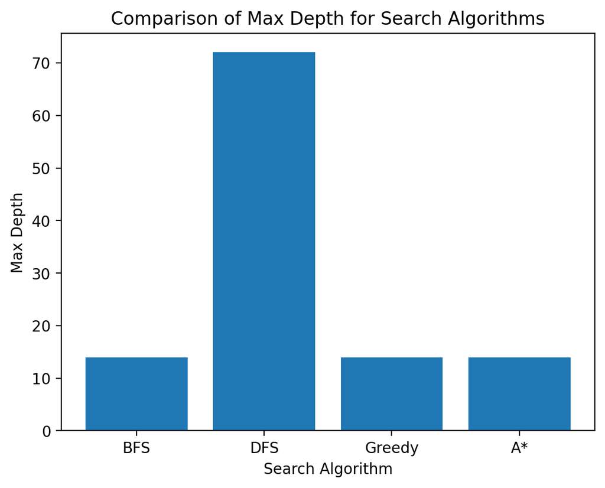

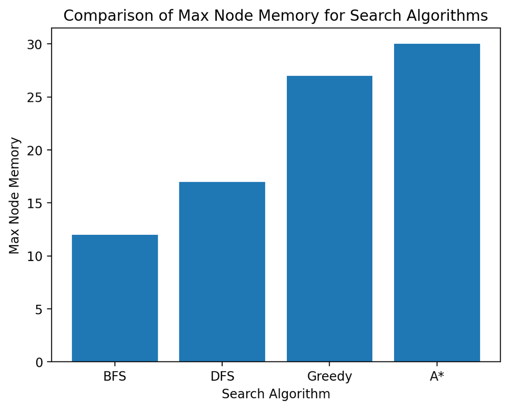

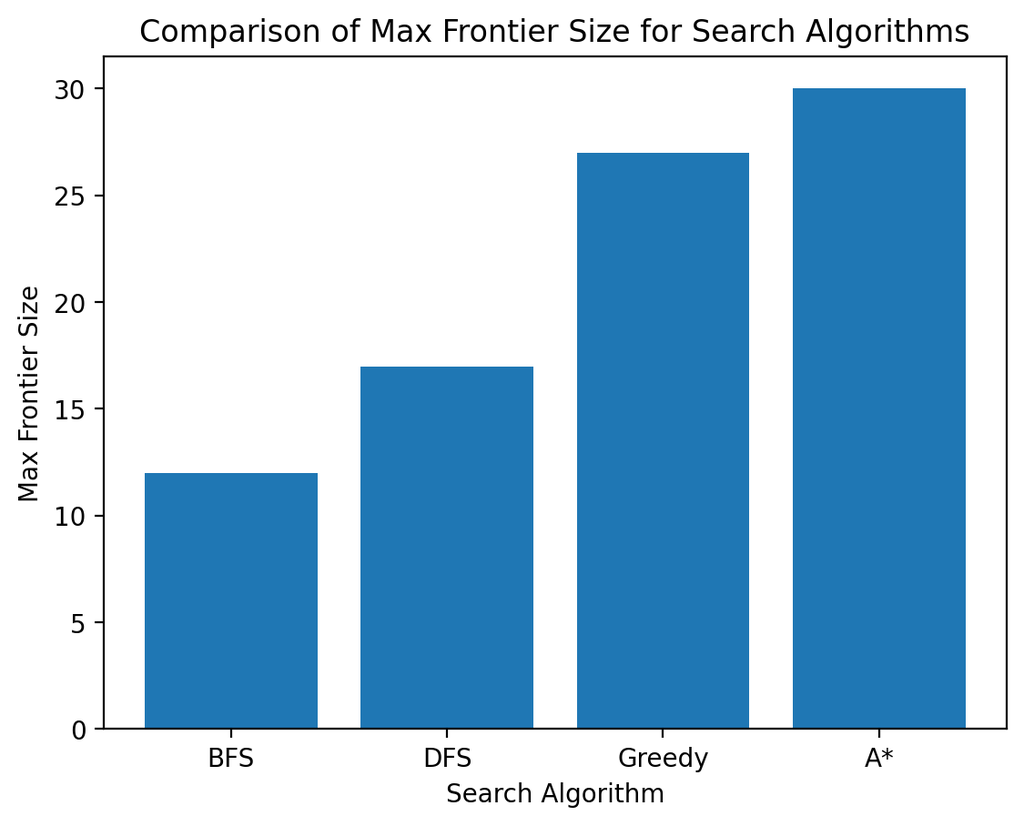

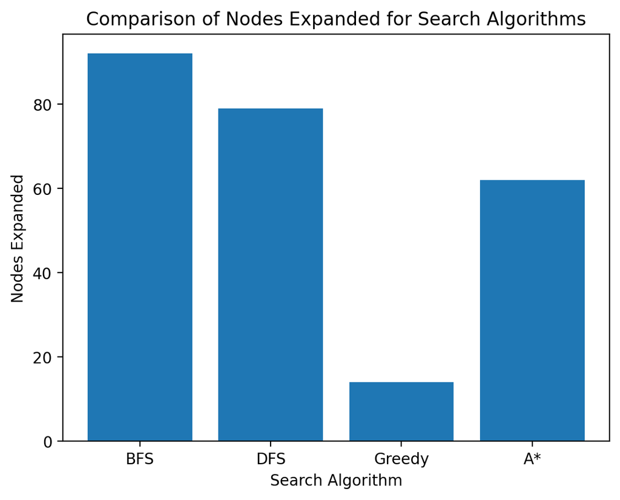

```python
# Generate the charts
path_costs = [result[1], resultdepth[1], resultgreedy[1], resulta[1]]
max_depths = [result[2], resultdepth[2], resultgreedy[2], resulta[2]]
max_node_memories = [result[3], resultdepth[3], resultgreedy[3], resulta[3]]
max_frontiers = [result[4], resultdepth[4], resultgreedy[4], resulta[4]]
nodes_expanded = [result[5], resultdepth[5], resultgreedy[5], resulta[5]]
metrics = {
    'Path Cost': path_costs,
    'Max Depth': max_depths,
    'Max Node Memory': max_node_memories,
    'Max Frontier Size': max_frontiers,
    'Nodes Expanded': nodes_expanded
}
for metric_name, values in metrics.items():
    plt.figure()
    plt.bar(algorithms, values)
    plt.title(f'Comparison of {metric_name} for Search Algorithms')
    plt.xlabel('Search Algorithm')
    plt.ylabel(metric_name)
    plt.show()
```

```
XXXXXXXXXXXX
X          X
X        S X
X          X
X          X
X          X
X          X
X          X
X          X
X G        X
X          X
XXXXXXXXXXXX
```

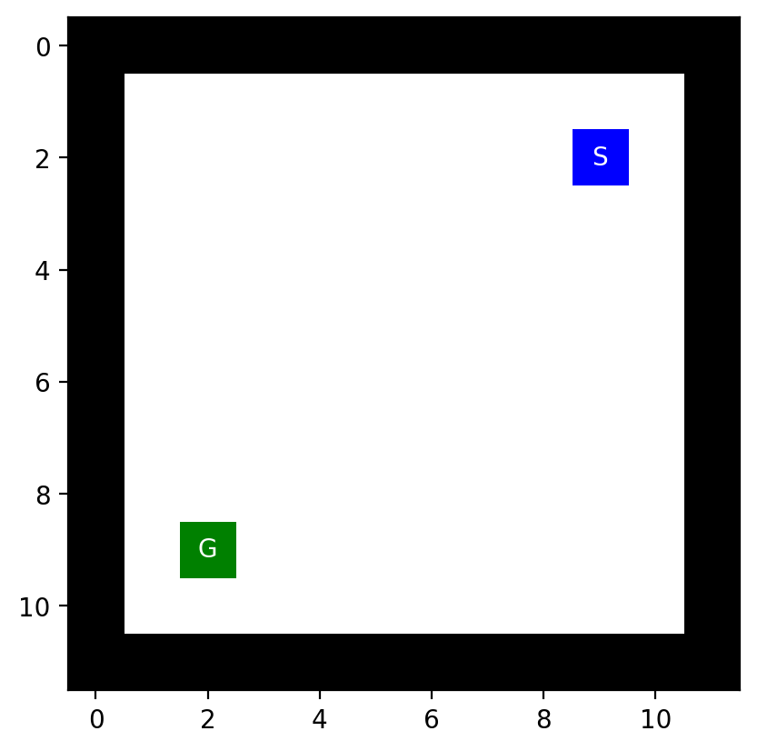

```
Path Cost: 14 ; Max Depth: 14 ; Max # of Nodes in Memory: 12 ; Max Frontier Size: 12 ; # of Nodes Expanded: 92
```

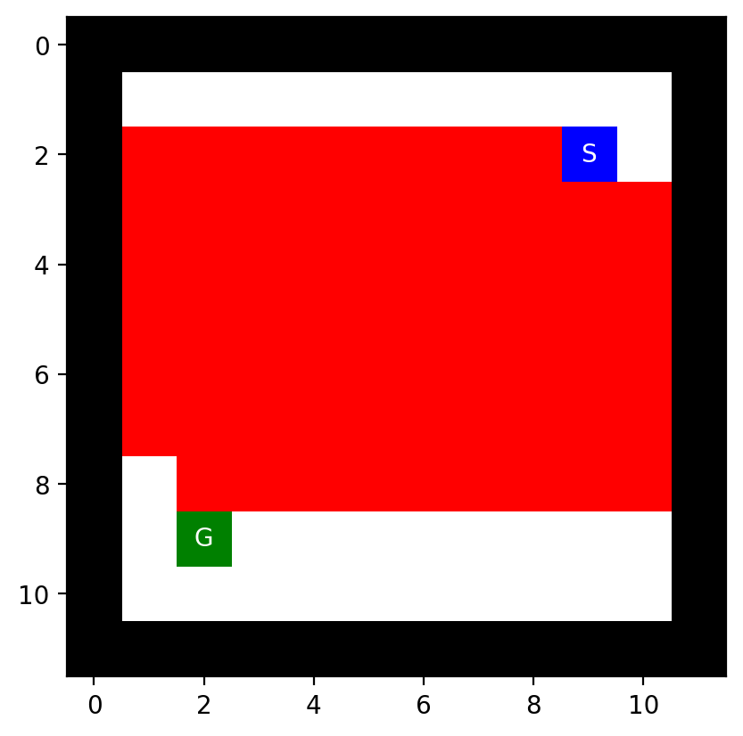

```
Path Cost: 68 ; Max Depth: 68 ; Max Node Memory: 20 ; Max Frontier: 20 ; Nodes Expanded: 68
```

```
Path Cost: 14 ; Max Depth: 14 ; Max Node Memory: 27 ; Max Frontier: 27 ; Nodes Expanded: 14
```

```
Path Cost: 14 ; Max Depth: 14 ; Max Node Memory: 30 ; Max Frontier: 30 ; Nodes Expanded: 62
```

```python
# Add code
with open("empty_2_maze.txt", "r") as f:
    maze_str = f.read()
maze = mh.parse_maze(maze_str)
print(maze_str)
mh.show_maze(maze)

# BFS
result = breadth_first_search(maze, mh.find_pos(maze, "S"), mh.find_pos(maze, "G"))
for node in result[0]:
    if maze[node.pos] not in ["S", "G"]:
        maze[node.pos] = "P"
mh.show_maze(maze)
print('Path Cost:', result[1], '; Max Depth:', result[2], '; Max # of Nodes in Memory:', result[3], '; Max Frontier Size:', result[4], '; # of Nodes Expanded:', result[5])

# DFS
resultdepth = depth_first_search(maze, mh.find_pos(maze, "S"), mh.find_pos(maze, "G"))
maze = mh.parse_maze(maze_str)
for node in resultdepth[0]:
    if maze[node.pos] not in ["S", "G"]:
        maze[node.pos] = "P"
mh.show_maze(maze)
print('Path Cost:', resultdepth[1], '; Max Depth:', resultdepth[2], '; Max Node Memory:', resultdepth[3], '; Max Frontier:', resultdepth[4], '; Nodes Expanded:', resultdepth[5])

# Greedy search
resultgreedy = greedy_best_first_search(maze, mh.find_pos(maze, "S"), mh.find_pos(maze, "G"))
maze = mh.parse_maze(maze_str)
for node in resultgreedy[0]:
    if maze[node.pos] not in ["S", "G"]:
        maze[node.pos] = "P"
mh.show_maze(maze)
print('Path Cost:', resultgreedy[1], '; Max Depth:', resultgreedy[2], '; Max Node Memory:', resultgreedy[3], '; Max Frontier:', resultgreedy[4], '; Nodes Expanded:', resultgreedy[5])

# a* search
resulta = a_breadth_first_search(maze, mh.find_pos(maze, "S"), mh.find_pos(maze, "G"))
maze = mh.parse_maze(maze_str)
for node in resulta[0]:
    if maze[node.pos] not in ["S", "G"]:
        maze[node.pos] = "P"
mh.show_maze(maze)
print('Path Cost:', resulta[1], '; Max Depth:', resulta[2], '; Max Node Memory:', resulta[3], '; Max Frontier:', resulta[4], '; Nodes Expanded:', resulta[5])
```

[output not shown]

```python
# Table
results = [
    ['BFS', result[1], result[2], result[3], result[4], result[5]],
    ['DFS', resultdepth[1], resultdepth[2], resultdepth[3], resultdepth[4], resultdepth[5]],
    ['Greedy Best-First', resultgreedy[1], resultgreedy[2], resultgreedy[3], resultgreedy[4], resultgreedy[5]],
    ['A* Search', resulta[1], resulta[2], resulta[3], resulta[4], resulta[5]]
]

columns = ['Algorithm', 'Path Cost', 'Max Depth', 'Max Nodes in Memory', 'Max Frontier Size', 'Nodes Expanded']

table = tabulate(results, headers=columns, tablefmt='grid')

print("Empty 2 Maze")
print(table)
```

```
Empty 2 Maze
+-------------------+-------------+-------------+-----------------------+---------------------+------------------+
| Algorithm         |   Path Cost |   Max Depth |   Max Nodes in Memory |   Max Frontier Size |   Nodes Expanded |
+===================+=============+=============+=======================+=====================+==================+
| BFS               |          14 |          14 |                    12 |                  12 |               92 |
+-------------------+-------------+-------------+-----------------------+---------------------+------------------+
| DFS               |          68 |          68 |                    20 |                  20 |               68 |
+-------------------+-------------+-------------+-----------------------+---------------------+------------------+
| Greedy Best-First |          14 |          14 |                    27 |                  27 |               14 |
+-------------------+-------------+-------------+-----------------------+---------------------+------------------+
| A* Search         |          14 |          14 |                    30 |                  30 |               62 |
+-------------------+-------------+-------------+-----------------------+---------------------+------------------+
```

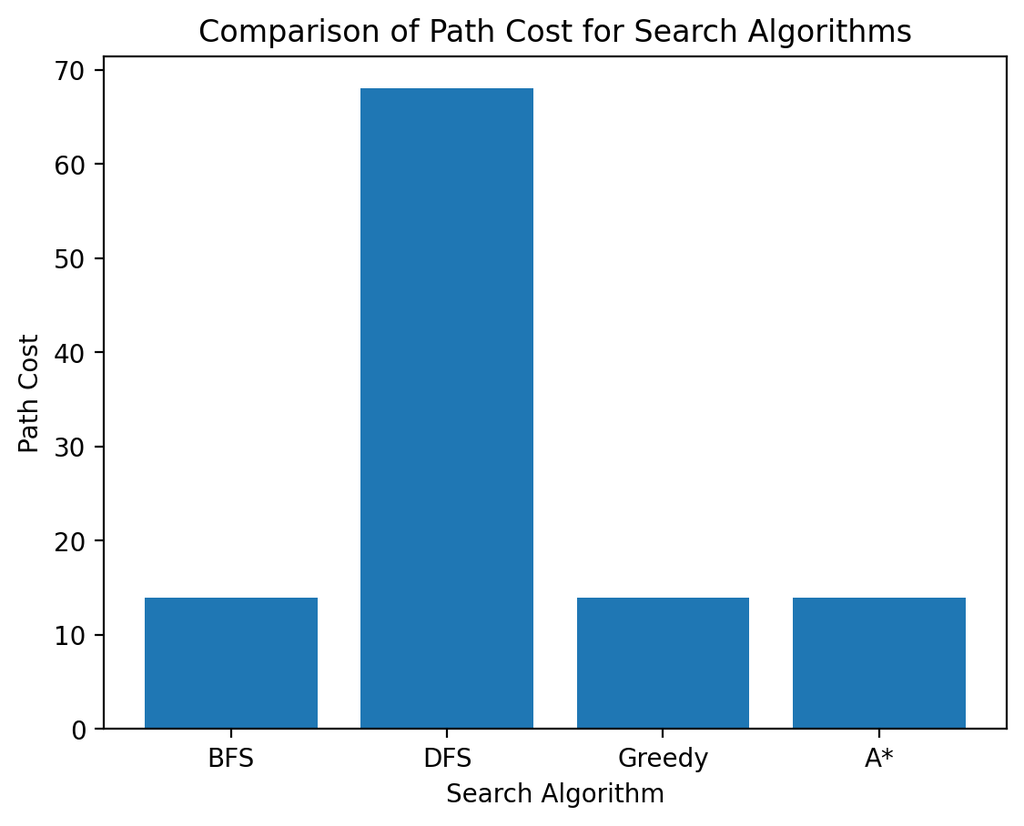

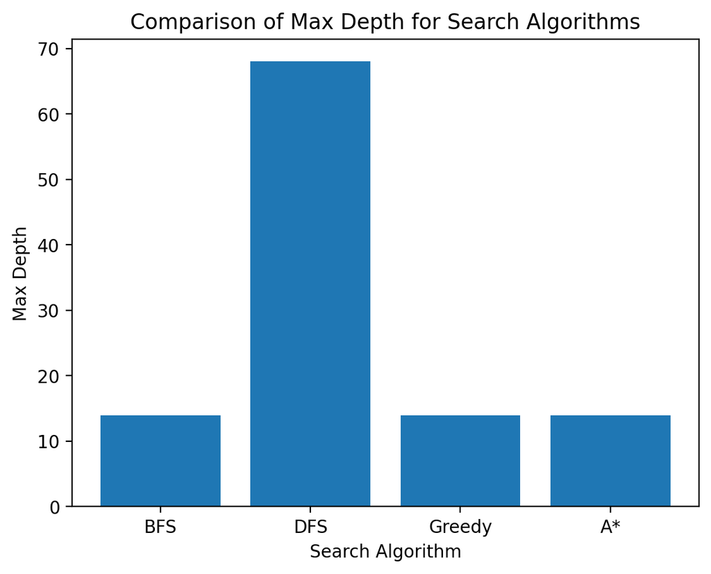

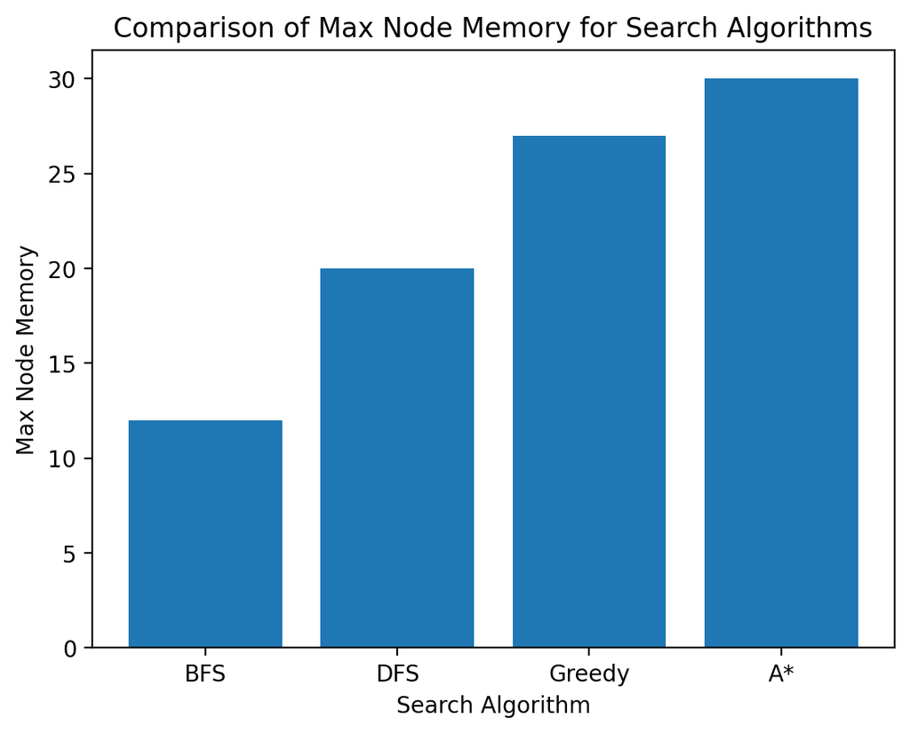

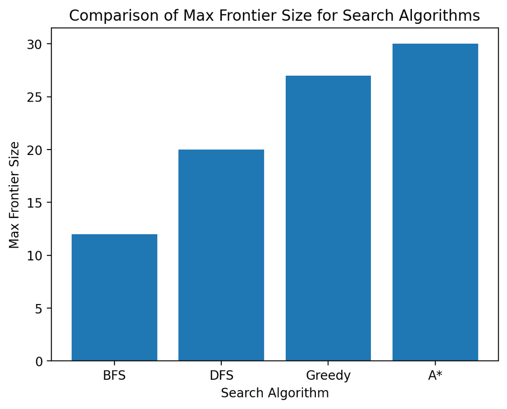

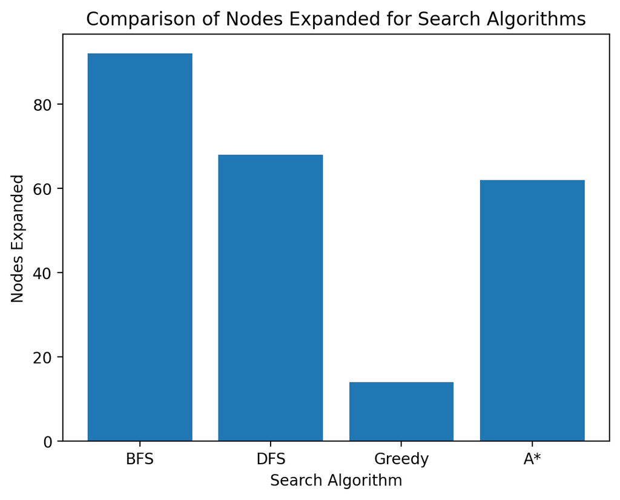

```python
# Generate the charts
path_costs = [result[1], resultdepth[1], resultgreedy[1], resulta[1]]
max_depths = [result[2], resultdepth[2], resultgreedy[2], resulta[2]]
max_node_memories = [result[3], resultdepth[3], resultgreedy[3], resulta[3]]
max_frontiers = [result[4], resultdepth[4], resultgreedy[4], resulta[4]]
nodes_expanded = [result[5], resultdepth[5], resultgreedy[5], resulta[5]]
metrics = {
    'Path Cost': path_costs,
    'Max Depth': max_depths,
    'Max Node Memory': max_node_memories,
    'Max Frontier Size': max_frontiers,
    'Nodes Expanded': nodes_expanded
}
for metric_name, values in metrics.items():
    plt.figure()
    plt.bar(algorithms, values)
    plt.title(f'Comparison of {metric_name} for Search Algorithms')
    plt.xlabel('Search Algorithm')
    plt.ylabel(metric_name)
    plt.show()
```

Present the results as using charts (see Python Code Examples/charts and tables).

# Add charts

Charts and table are shown above

Discuss the most important lessons you have learned from implementing the different search strategies.

# Add discussion

For me, implementing BFS was relatively straightfoward, however, implementing DFS was a bit more difficult. My first version of the DFS search would fail in mazes with lots of open room, most likely because it would keep going in circles. Thanks to a suggestion on the Canvas discussion board, I realized that I had to check stack does not contain the same state more than once, so I had to make sure that my algorithm checked the stack and remove the original node if the node already exists before adding.

Implemnting Greedy Best first search was also relatively straightfoward because I just needed to make an extra function to calculate the manhattan distance, and to use that distance to find the closest node to its current position. A* search gave me more trouble because I had to take the cost of the path into account to avoid continuing a path that was already expensive when another path exists that is more optimal.

GBFS and A* has the same path cost and max depth about half of the time, which is most likely because GBFS goes to the closest node, which can be optimal, but can sometimes not if the path overall is not optimal. Therefore, GBFS and A* can get similar results depending on the structure of the maze.

DFS performs the worse overall, as it has the highest path cost and max depth out of all the searches. What is interesting is that it does not always have the highest nodes expanded compared to all the searches.

## Advanced task: IDS and Multiple goals

- **Graduate students** need to complete this task [10 points]
- **Undergraduate students** can attempt this as a bonus task [max +5 bonus points].

### IDS

Implement IDS (iterative deepening search) using your DFS implementation. Test IDS on the mazes above. You may run into some issues with mazes with open spaces. If you cannot resolve the issus, then report and discuss what causes the problems.

```python
# Your code/answer goes here
```

# Multiple Goals

Create a few mazes with multiple goals by adding one or two more goals to the medium size maze. The agent is done when it finds one of the goals. Solve the maze with your implementations for DFS, BFS, and IDS. Run experiments to show which implementations find the optimal solution and which do not. Discuss why that is the case.

```python
# Your code/answer goes here
```

## More advanced tasks to think about

### Intersection as states

Instead of defining each square as a state, use only intersections as states. Now the storage requirement is reduced, but the path length between two intersections can be different. If we use total path length measured as the number of squares as path cost, how can we make sure that BFS and iterative deepening search is optimal? Change the code to do so.

```python
# Your code/answer goes here
```

### Weighted A* search

Modify your A* search to add weights (see text book) and explore how different weights influence the result.

```python
# Your code/answer goes here
```

### Unknown Maze

What happens if the agent does not know the layout of the maze in advance? This means that the agent faces an unknown environment, where it does not know the transition function. How does the environment look then (PEAS description)? How would you implement a rational agent to solve the maze? What if the agent still has a GPS device to tell the distance to the goal?

```python
# Your code/answer goes here
```